Student ID: A0296685E NAME: CHAI JIAYING

# Loan Default Prediction

## 1. Introduction

Financial loan services are widely used by banks, financial institutions, and government entities to manage lending risks. By using machine learning to predict potential loan defaults, companies can proactively identify high-risk individuals, enabling timely interventions to minimize financial losses and improve repayment compliance.

Goal: To predict loan default risk accurately using machine learning models trained on sample data.

### 1.1 Load Dataset

Data source:https://www.kaggle.com/datasets/nikhil1e9/loan-default/data

```python
import numpy as np
import pandas as pd
data = pd.read_csv('E:/0AAANUS/sem1/hw-ml/Loan_default.csv')
pd.Series(data['Default']).value_counts()
```

```
Default
0    225694
1     29653
Name: count, dtype: int64
```

```python
data.head()
```

|  | LoanID | Age | Income | LoanAmount | CreditScore | MonthsEmployed | NumCreditLines | InterestRate | LoanTerm | DTIRatio | Education | EmploymentType | MaritalStatus | HasMortgage | HasDependents | LoanPurpose | HasCoSigner | Default |
| --- | --- | --- | --- | --- | --- | --- | --- | --- | --- | --- | --- | --- | --- | --- | --- | --- | --- | --- |
| 0 | I38PQUQS96 | 56 | 85994 | 50587 | 520 | 80 | 4 | 15.23 | 36 | 0.44 | Bachelor's | Full-time | Divorced | Yes | Yes | Other | Yes | 0 |
| 1 | HPSK72WA7R | 69 | 50432 | 124440 | 458 | 15 | 1 | 4.81 | 60 | 0.68 | Master's | Full-time | Married | No | No | Other | Yes | 0 |
| 2 | C1OZ6DPJ8Y | 46 | 84208 | 129188 | 451 | 26 | 3 | 21.17 | 24 | 0.31 | Master's | Unemployed | Divorced | Yes | Yes | Auto | No | 1 |
| 3 | V2KKSFM3UN | 32 | 31713 | 44799 | 743 | 0 | 3 | 7.07 | 24 | 0.23 | High School | Full-time | Married | No | No | Business | No | 0 |
| 4 | EY08JDHTZP | 60 | 20437 | 9139 | 633 | 8 | 4 | 6.51 | 48 | 0.73 | Bachelor's | Unemployed | Divorced | No | Yes | Auto | No | 0 |

The dataset contains 255,347 rows and 18 columns. And we can see the dataset is unbalanced, so take a subsample with an equal ratio of positive and negative samples, which will be helpful to provide better performance in model training.

```python
# Take a subsample with an equal ratio of positive and negative samples.
dataX = data.groupby("Default").sample(n=25000,random_state=0)
dataX.info()
dataX.shape
# Eliminate the first column: "LoanID" which does not provide us with value.
dataX.drop("LoanID", axis = 1, inplace = True)
dataX.head()
```

```
<class 'pandas.core.frame.DataFrame'>
Index: 50000 entries, 95355 to 254718
Data columns (total 18 columns):
 #   Column          Non-Null Count  Dtype
---  ------          --------------  -----
 0   LoanID          50000 non-null  object
 1   Age             50000 non-null  int64
 2   Income          50000 non-null  int64
 3   LoanAmount      50000 non-null  int64
 4   CreditScore     50000 non-null  int64
 5   MonthsEmployed  50000 non-null  int64
 6   NumCreditLines  50000 non-null  int64
 7   InterestRate    50000 non-null  float64
 8   LoanTerm        50000 non-null  int64
 9   DTIRatio        50000 non-null  float64
 10  Education       50000 non-null  object
 11  EmploymentType  50000 non-null  object
 12  MaritalStatus   50000 non-null  object
 13  HasMortgage     50000 non-null  object
 14  HasDependents   50000 non-null  object
 15  LoanPurpose     50000 non-null  object
 16  HasCoSigner     50000 non-null  object
 17  Default         50000 non-null  int64
dtypes: float64(2), int64(8), object(8)
memory usage: 7.2+ MB
```

|  | Age | Income | LoanAmount | CreditScore | MonthsEmployed | NumCreditLines | InterestRate | LoanTerm | DTIRatio | Education | EmploymentType | MaritalStatus | HasMortgage | HasDependents | LoanPurpose | HasCoSigner | Default |
| --- | --- | --- | --- | --- | --- | --- | --- | --- | --- | --- | --- | --- | --- | --- | --- | --- | --- |
| 95355 | 27 | 81038 | 154484 | 537 | 9 | 1 | 20.88 | 60 | 0.82 | Master's | Part-time | Divorced | Yes | Yes | Home | Yes | 0 |
| 159845 | 48 | 20311 | 195425 | 810 | 93 | 1 | 23.21 | 60 | 0.80 | PhD | Unemployed | Single | Yes | No | Business | Yes | 0 |
| 30780 | 63 | 98186 | 60094 | 541 | 99 | 1 | 8.77 | 24 | 0.86 | Master's | Part-time | Single | No | Yes | Business | No | 0 |
| 106899 | 62 | 29126 | 22173 | 583 | 72 | 4 | 12.03 | 60 | 0.85 | PhD | Unemployed | Divorced | Yes | Yes | Business | Yes | 0 |
| 175268 | 21 | 55263 | 24396 | 433 | 69 | 4 | 13.82 | 24 | 0.64 | High School | Part-time | Married | Yes | Yes | Home | No | 0 |

```python
pd.Series(dataX['Default']).value_counts()
```

```
Default
0    25000
1    25000
Name: count, dtype: int64
```

Check missing data

```python
# check missing data
print(dataX.shape)
print('\t')
print(dataX.isnull().sum())
print('\t')
data.info()
```

```
(50000, 17)

Age               0
Income            0
LoanAmount        0
CreditScore       0
MonthsEmployed    0
NumCreditLines    0
InterestRate      0
LoanTerm          0
DTIRatio          0
Education         0
EmploymentType    0
MaritalStatus     0
HasMortgage       0
HasDependents     0
LoanPurpose       0
HasCoSigner       0
Default           0
dtype: int64

<class 'pandas.core.frame.DataFrame'>
RangeIndex: 255347 entries, 0 to 255346
Data columns (total 18 columns):
 #   Column          Non-Null Count   Dtype
---  ------          --------------   -----
 0   LoanID          255347 non-null  object
 1   Age             255347 non-null  int64
 2   Income          255347 non-null  int64
 3   LoanAmount      255347 non-null  int64
 4   CreditScore     255347 non-null  int64
 5   MonthsEmployed  255347 non-null  int64
 6   NumCreditLines  255347 non-null  int64
 7   InterestRate    255347 non-null  float64
 8   LoanTerm        255347 non-null  int64
 9   DTIRatio        255347 non-null  float64
 10  Education       255347 non-null  object
 11  EmploymentType  255347 non-null  object
 12  MaritalStatus   255347 non-null  object
 13  HasMortgage     255347 non-null  object
 14  HasDependents   255347 non-null  object
 15  LoanPurpose     255347 non-null  object
 16  HasCoSigner     255347 non-null  object
 17  Default         255347 non-null  int64
dtypes: float64(2), int64(8), object(8)
memory usage: 35.1+ MB
```

The result shows that there is no missing data.

### 1.2 Visualize Data

#### 1.2.1 Descriptive Statistics

```python
description = dataX.describe()
description
```

|  | Age | Income | LoanAmount | CreditScore | MonthsEmployed | NumCreditLines | InterestRate | LoanTerm | DTIRatio | Default |
| --- | --- | --- | --- | --- | --- | --- | --- | --- | --- | --- |
| count | 50000.000000 | 50000.000000 | 50000.00000 | 50000.000000 | 50000.000000 | 50000.000000 | 50000.000000 | 50000.000000 | 50000.000000 | 50000.000000 |
| mean | 40.463540 | 78008.521000 | 135023.82796 | 568.114320 | 55.444840 | 2.545140 | 14.512176 | 36.107520 | 0.503735 | 0.500000 |
| std | 14.913339 | 40200.265985 | 70698.19104 | 159.014732 | 34.603072 | 1.121137 | 6.602441 | 17.026981 | 0.230644 | 0.500005 |
| min | 18.000000 | 15000.000000 | 5012.00000 | 300.000000 | 0.000000 | 1.000000 | 2.000000 | 12.000000 | 0.100000 | 0.000000 |
| 25% | 27.000000 | 41712.750000 | 74677.25000 | 430.000000 | 25.000000 | 2.000000 | 8.980000 | 24.000000 | 0.310000 | 0.000000 |
| 50% | 39.000000 | 76597.000000 | 138711.00000 | 565.000000 | 53.000000 | 3.000000 | 14.990000 | 36.000000 | 0.510000 | 0.500000 |
| 75% | 53.000000 | 112980.250000 | 197439.75000 | 705.000000 | 85.000000 | 4.000000 | 20.310000 | 48.000000 | 0.700000 | 1.000000 |
| max | 69.000000 | 149999.000000 | 249993.00000 | 849.000000 | 119.000000 | 4.000000 | 25.000000 | 60.000000 | 0.900000 | 1.000000 |

#### 1.2.2 Visulize the numerical features and the categorical features.

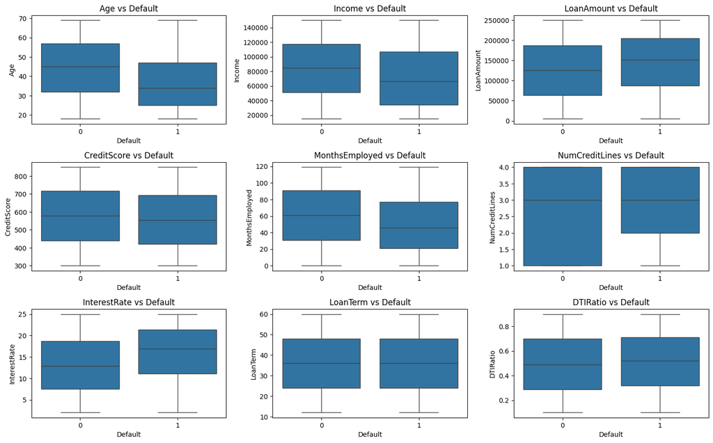

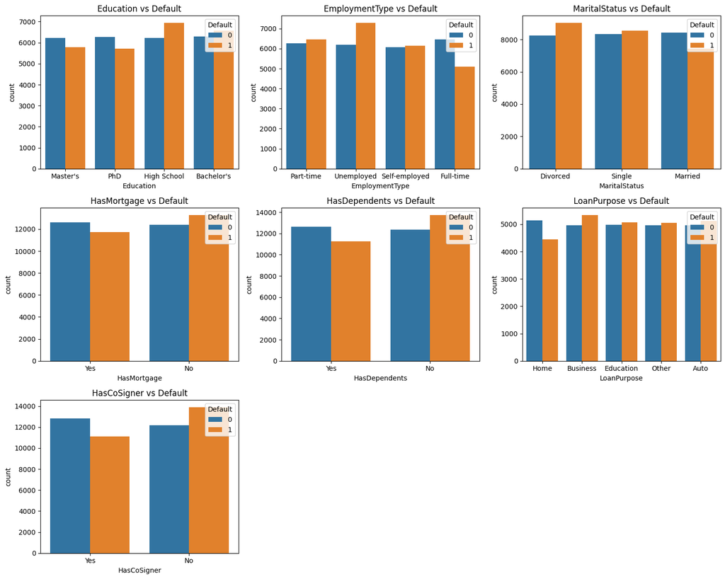

```python
import matplotlib.pyplot as plt
import seaborn as sns

num_features = ['Age', 'Income', 'LoanAmount', 'CreditScore', 'MonthsEmployed', 'NumCreditLines', 'InterestRate', 'LoanTerm', 'DTIRatio']
cat_features = ['Education', 'EmploymentType', 'MaritalStatus', 'HasMortgage', 'HasDependents', 'LoanPurpose', 'HasCoSigner']

fig, axes = plt.subplots(len(num_features)//3 + 1, 3, figsize=(15, 12))

# plot numerical features
for i, feature in enumerate(num_features):
    ax = axes[i//3, i%3]
    sns.boxplot(x='Default', y=feature, data=dataX, ax=ax)
    ax.set_title(f'{feature} vs Default')

for i in range(len(num_features), len(axes.flatten())):
    fig.delaxes(axes.flatten()[i])

plt.tight_layout()
plt.show()

fig, axes = plt.subplots(len(cat_features)//3 + 1, 3, figsize=(15, 12))

# plot categorical features
for i, feature in enumerate(cat_features):
    ax = axes[i//3, i%3]
    sns.countplot(x=feature, hue='Default', data=dataX, ax=ax)
    ax.set_title(f'{feature} vs Default')


for i in range(len(cat_features), len(axes.flatten())):
    fig.delaxes(axes.flatten()[i])

plt.tight_layout()
plt.show()
```

**Interpretation:**

for numerical features:  
a. Older people are seen less likely to default  
b. The dafaulters are seen with lower avg income  
c. The dafaulters are seen with larger Loan Amount and lesser credit score  
d. People having higher Interest rate are more likely to default  
for categorical features:  
a. Higher education people are seen less likely to default  
b. Unemployed people are seen more likely to default  
c. People without mortgage or dependent or co-signer are more likely to default

#### 1.2.3 Correlation Matrix

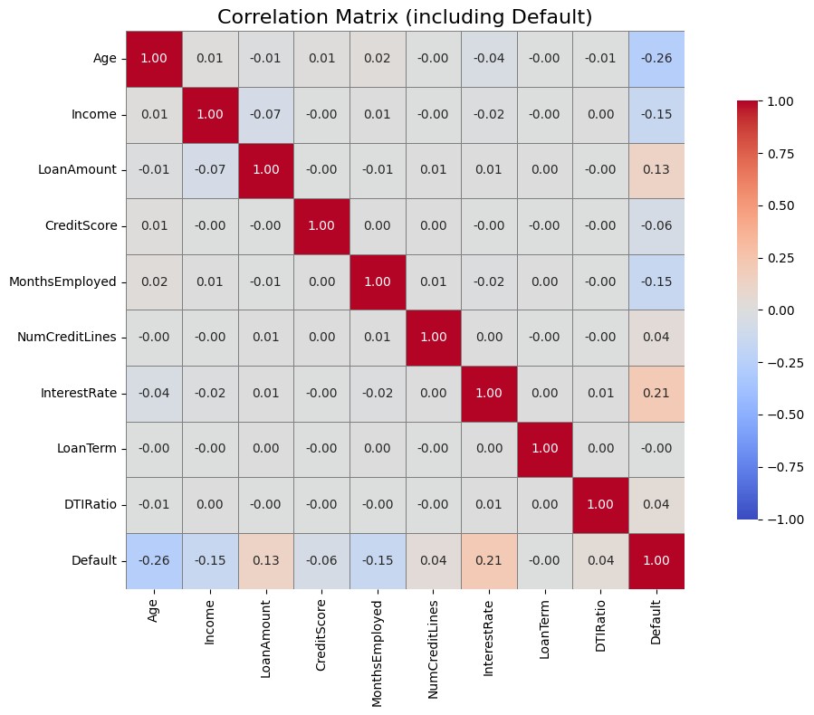

```python
# correlation
features_with_default = num_features + ['Default']
corr_matrix = dataX[features_with_default].corr()

plt.figure(figsize=(12, 8))
sns.heatmap(corr_matrix, annot=True, fmt='.2f', cmap='coolwarm', vmin=-1, vmax=1, center=0,
            linewidths=0.5, linecolor='gray', square=True, cbar_kws={"shrink": 0.75})
plt.title("Correlation Matrix (including Default)", fontsize=16)
plt.tight_layout()
plt.show()
```

**Interpretation:**  
There is no significant correlation between features.  
We can find that the top few features that have an important impact on whether it is default are  
Age -0.26  
Interest Rate 0.21  
Income -0.15  
MonthsEmployed -0.15  
LoanAmount 0.13

### 1.3 Preprocessing Data

#### 1.3.1 Feature Engineering

The two features **Loan-To-Income Ratio** and **Credit-Utilization Rate** are added to the model considering personal loan default, mainly to better quantify the relationship between the borrower's repayment ability and default risk:

The feature of **Loan Amount/Income** can effectively measure the debt burden of borrowers. Borrowers with higher Loan-To-Income Ratio may have higher default risk.  
The **Loan Amount/Credit Score** typically reflects the borrower's credit history and ability to repay. A high credit utilization ratio may indicate that a borrower is taking on more debt than his or her credit can handle, and thus may carry a higher risk of default.

```python
dataX['LoanToIncomeRatio'] = dataX['LoanAmount'] / dataX['Income']
dataX['CreditUtilizationRate'] = dataX['LoanAmount'] / dataX['CreditScore']
```

#### 1.3.2 Lable Encoder

The data set is preprocessed to convert classified and binary data into numerical format using **Label Encoding** and **One-Hot Encoding** so that it can be directly used in machine learning models.

```python
#convert categorical and binary data into numerical values
from sklearn.preprocessing import LabelEncoder
le = LabelEncoder()
binary_columns = ['HasMortgage', 'HasDependents', 'HasCoSigner']
# Apply LabelEncoder to binary columns
for col in binary_columns:
    dataX[col] = le.fit_transform(dataX[col])
# One-hot encoding categorical columns
categorical_columns = ['Education', 'EmploymentType', 'MaritalStatus', 'LoanPurpose']
# Apply one-hot encoding
dataX = pd.get_dummies(dataX, columns=categorical_columns, drop_first=True).astype(float)  # drop_first=True avoids multicollinearity
```

```python
pd.set_option('display.max_columns',None)
dataX
dataX.info()
```

```
<class 'pandas.core.frame.DataFrame'>
Index: 50000 entries, 95355 to 254718
Data columns (total 27 columns):
 #   Column                        Non-Null Count  Dtype
---  ------                        --------------  -----
 0   Age                           50000 non-null  float64
 1   Income                        50000 non-null  float64
 2   LoanAmount                    50000 non-null  float64
 3   CreditScore                   50000 non-null  float64
 4   MonthsEmployed                50000 non-null  float64
 5   NumCreditLines                50000 non-null  float64
 6   InterestRate                  50000 non-null  float64
 7   LoanTerm                      50000 non-null  float64
 8   DTIRatio                      50000 non-null  float64
 9   HasMortgage                   50000 non-null  float64
```

[output cut: 19 more lines]

#### 1.3.3 Standard Scaler

The order of magnitude difference between the different features is very large, so consider normalizing the data. The SVM model requires that the data conform to the standard normal distribution, then StandardScaler is used.

```python
from sklearn.preprocessing import StandardScaler

# List of numerical columns to scale
numerical_columns = ['Age', 'Income', 'LoanAmount', 'CreditScore', 'MonthsEmployed',
                     'NumCreditLines', 'InterestRate', 'LoanTerm', 'DTIRatio', 'LoanToIncomeRatio' , 'CreditUtilizationRate']
scaler = StandardScaler()
dataX[numerical_columns] = scaler.fit_transform(dataX[numerical_columns])
dataX.head()
```

|  | Age | Income | LoanAmount | CreditScore | MonthsEmployed | NumCreditLines | InterestRate | LoanTerm | DTIRatio | HasMortgage | HasDependents | HasCoSigner | Default | LoanToIncomeRatio | CreditUtilizationRate | Education_High School | Education_Master's | Education_PhD | EmploymentType_Part-time | EmploymentType_Self-employed | EmploymentType_Unemployed | MaritalStatus_Married | MaritalStatus_Single | LoanPurpose_Business | LoanPurpose_Education | LoanPurpose_Home | LoanPurpose_Other |
| --- | --- | --- | --- | --- | --- | --- | --- | --- | --- | --- | --- | --- | --- | --- | --- | --- | --- | --- | --- | --- | --- | --- | --- | --- | --- | --- | --- |
| 95355 | -0.902794 | 0.075360 | 0.275260 | -0.195671 | -1.342231 | -1.378204 | 0.964475 | 1.403227 | 1.371240 | 1.0 | 1.0 | 1.0 | 0.0 | -0.273324 | 0.175900 | 0.0 | 1.0 | 0.0 | 1.0 | 0.0 | 0.0 | 0.0 | 0.0 | 0.0 | 0.0 | 1.0 | 0.0 |
| 159845 | 0.505355 | -1.435267 | 0.854361 | 1.521168 | 1.085324 | -1.378204 | 1.317378 | 1.403227 | 1.284525 | 1.0 | 0.0 | 1.0 | 0.0 | 2.580602 | -0.109638 | 0.0 | 0.0 | 1.0 | 0.0 | 0.0 | 1.0 | 0.0 | 1.0 | 1.0 | 0.0 | 0.0 | 0.0 |
| 30780 | 1.511176 | 0.501929 | -1.059866 | -0.170516 | 1.258720 | -1.378204 | -0.869714 | -0.711086 | 1.544670 | 0.0 | 1.0 | 0.0 | 0.0 | -0.752081 | -0.910537 | 0.0 | 1.0 | 0.0 | 1.0 | 0.0 | 0.0 | 0.0 | 1.0 | 1.0 | 0.0 | 0.0 | 0.0 |
| 106899 | 1.444122 | -1.215987 | -1.596250 | 0.093613 | 0.478435 | 1.297678 | -0.375952 | 1.403227 | 1.501312 | 1.0 | 1.0 | 1.0 | 0.0 | -0.696878 | -1.359918 | 0.0 | 0.0 | 1.0 | 0.0 | 0.0 | 1.0 | 0.0 | 0.0 | 1.0 | 0.0 | 0.0 | 0.0 |
| 175268 | -1.305123 | -0.565811 | -1.564806 | -0.849705 | 0.391737 | 1.297678 | -0.104837 | -0.711086 | 0.590808 | 1.0 | 1.0 | 0.0 | 0.0 | -0.815183 | -1.247281 | 1.0 | 0.0 | 0.0 | 1.0 | 0.0 | 0.0 | 1.0 | 0.0 | 0.0 | 0.0 | 1.0 | 0.0 |

#### 1.3.4 Splitting the dataset

```python
from sklearn.model_selection import train_test_split

# Split the dataset into features and target variable
X = dataX.drop('Default', axis=1)  # Features
y = dataX['Default']  # Target variable

# Train-test split (80% train, 20% test)
X_train, X_test, y_train, y_test = train_test_split(X, y, test_size=0.2, random_state=42)

# Print the shape of the resulting datasets
print("Training set shape:", X_train.shape)
print("Testing set shape:", X_test.shape)
```

```
Training set shape: (40000, 26)
Testing set shape: (10000, 26)
```

```python
pd.Series(y_test).value_counts()
```

```
Default
0.0    5022
1.0    4978
Name: count, dtype: int64
```

## 2. Supervised Learning

Choose three supervised learning model: random forest, SVM, and XGBoost.

### 2.1 Random Forest

```python
from sklearn.metrics import accuracy_score, classification_report, confusion_matrix
from sklearn.tree import DecisionTreeClassifier
from sklearn.model_selection import GridSearchCV
from sklearn.ensemble import RandomForestClassifier, GradientBoostingClassifier, AdaBoostClassifier, ExtraTreesClassifier
```

K-Fold Cross-Validation

```python
from sklearn.ensemble import RandomForestClassifier
from sklearn.model_selection import cross_val_score, KFold
from sklearn.metrics import accuracy_score, classification_report, confusion_matrix

rf_model = RandomForestClassifier(n_estimators=1000, random_state=1, max_features="sqrt", max_depth=34, criterion="entropy")

# K-Fold
kfold = KFold(n_splits=5, shuffle=True, random_state=1)

# Use K-Fold for cross validation and calculate accuracy
cv_scores = cross_val_score(rf_model, X_train, y_train, cv=kfold, scoring='accuracy')

# Output the score and average score of each fold
print("Cross-validation scores for each fold:", cv_scores)
print("Average cross-validation accuracy: {:.2f}%".format(cv_scores.mean() * 100))
```

```
Cross-validation scores for each fold: [0.681375 0.68625  0.667    0.679375 0.680125]
Average cross-validation accuracy: 67.88%
```

Train the Model

```python
rf_model.fit(X_train, y_train)

rf_predictions = rf_model.predict(X_test)

print("\nRandom Forest Classifier with K-Fold Cross-Validation:")
print("Test Accuracy:", accuracy_score(y_test, rf_predictions))
print("Classification Report:\n", classification_report(y_test, rf_predictions))
print("Confusion Matrix:\n", confusion_matrix(y_test, rf_predictions))
```

```
Random Forest Classifier with K-Fold Cross-Validation:
Test Accuracy: 0.6862
Classification Report:
               precision    recall  f1-score   support

         0.0       0.68      0.70      0.69      5022
         1.0       0.69      0.67      0.68      4978

    accuracy                           0.69     10000
   macro avg       0.69      0.69      0.69     10000
weighted avg       0.69      0.69      0.69     10000

Confusion Matrix:
 [[3510 1512]
 [1626 3352]]
```

Confusion Matrix

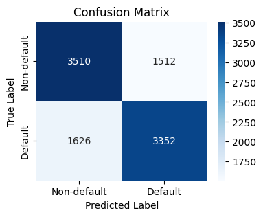

```python
conf_matrix = confusion_matrix(y_test, rf_predictions)

plt.figure(figsize=(4, 3))
sns.heatmap(conf_matrix, annot=True, fmt='d', cmap='Blues', xticklabels=['Non-default', 'Default'], yticklabels=['Non-default', 'Default'])
plt.xlabel('Predicted Label')
plt.ylabel('True Label')
plt.title('Confusion Matrix')
plt.show()
importances = rf_model.feature_importances_
std = np.std([tree.feature_importances_ for tree in rf_model.estimators_], axis=0)
```

Feature Importance

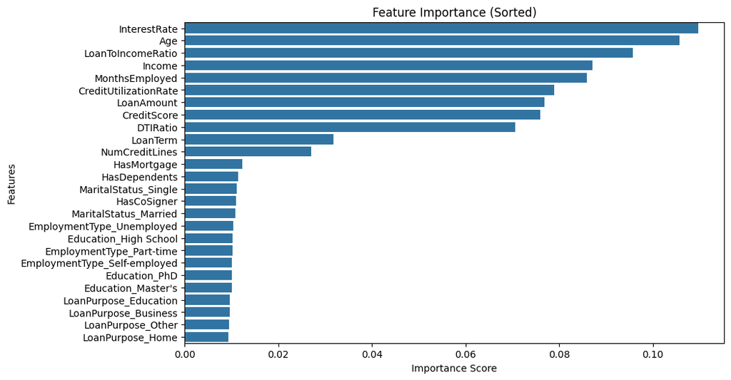

```python
feature_importances = rf_model.feature_importances_
# Sort index by feature importance
sorted_idx = np.argsort(feature_importances)[::-1]

sorted_features = X.columns[sorted_idx]
sorted_importances = feature_importances[sorted_idx]

plt.figure(figsize=(10, 6))
sns.barplot(x=sorted_importances, y=sorted_features)
plt.title("Feature Importance (Sorted)")
plt.xlabel("Importance Score")
plt.ylabel("Features")
plt.show()
```

The top 3 important features are InterestRate, Age, LoanToIncomeRatio.

ROC Curve

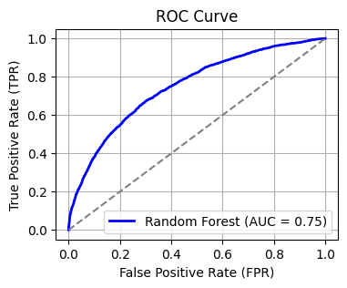

```
Random Forest Classifier AUC: 0.7481934050243213
```

```python
from sklearn.metrics import roc_curve, auc
import matplotlib.pyplot as plt

# Get the model's predicted probability for the test set
rf_probabilities = rf_model.predict_proba(X_test)[:, 1]  # The probability of selecting the positive class

# Calculate FPR, TPR and threshold
fpr, tpr, thresholds = roc_curve(y_test, rf_probabilities)

# Calculate AUC
roc_auc = auc(fpr, tpr)

plt.figure(figsize=(4, 3))
plt.plot(fpr, tpr, color='blue', lw=2, label=f'Random Forest (AUC = {roc_auc:.2f})')
plt.plot([0, 1], [0, 1], color='grey', linestyle='--')  # 绘制对角线（代表随机猜测）

plt.xlabel('False Positive Rate (FPR)')
plt.ylabel('True Positive Rate (TPR)')
plt.title('ROC Curve')
plt.legend(loc='lower right')
plt.grid()
plt.show()

# Print AUC score
print("Random Forest Classifier AUC:", roc_auc)
```

Precision Recall Curve

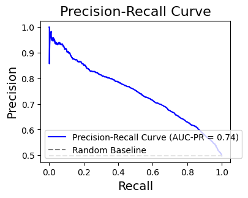

```
Precision-Recall AUC: 0.745
```

```python
from sklearn.metrics import average_precision_score

# Get the predicted probability of the positive class
rf_probabilities = rf_model.predict_proba(X_test)[:, 1]

# Compute Precision-Recall curve
precision, recall, thresholds = precision_recall_curve(y_test, rf_probabilities)
pr_auc = average_precision_score(y_test, rf_probabilities)

# 绘制 PR 曲线
plt.figure(figsize=(4, 3))
plt.plot(recall, precision, color='b', label=f'Precision-Recall Curve (AUC-PR = {pr_auc:.2f})')

# 水平基线
plt.hlines(y=np.mean(y_test), xmin=0, xmax=1, linestyle='--', color='gray', label='Random Baseline')

# 添加标题和标签
plt.title("Precision-Recall Curve", fontsize=16)
plt.xlabel("Recall", fontsize=14)
plt.ylabel("Precision", fontsize=14)
plt.legend(loc="lower left")

# 显示图形
plt.show()

pr_auc = auc(recall, precision)
print(f"Precision-Recall AUC: {pr_auc:.3f}")
```

### 2.2 SVM

```python
from sklearn.svm import SVC
from sklearn.metrics import accuracy_score, classification_report, confusion_matrix
```

K-Fold Cross-Validation

choose poly kernel.

```python
svm_model = SVC(kernel='poly',C=0.03,gamma='scale',probability=True)
kfold = KFold(n_splits=5, shuffle=True, random_state=1)

cv_scores = cross_val_score(svm_model, X_train, y_train, cv=kfold, scoring='accuracy')

print("Cross-validation scores for each fold:", cv_scores)
print("Average cross-validation accuracy: {:.2f}%".format(cv_scores.mean() * 100))
```

```
Cross-validation scores for each fold: [0.690625 0.685875 0.675875 0.68475  0.68525 ]
Average cross-validation accuracy: 68.45%
```

Train the Model

```python
svm_model.fit(X_train, y_train)

svm_predictions = svm_model.predict(X_test)

print("\nSVM Classifier with K-Fold Cross-Validation:")
print("Test Accuracy:", accuracy_score(y_test, svm_predictions))
print("Classification Report:\n", classification_report(y_test, svm_predictions))
print("Confusion Matrix:\n", confusion_matrix(y_test, svm_predictions))
```

```
SVM Classifier with K-Fold Cross-Validation:
Test Accuracy: 0.691
Classification Report:
               precision    recall  f1-score   support

         0.0       0.70      0.68      0.69      5022
         1.0       0.68      0.70      0.69      4978

    accuracy                           0.69     10000
   macro avg       0.69      0.69      0.69     10000
weighted avg       0.69      0.69      0.69     10000

Confusion Matrix:
 [[3408 1614]
 [1476 3502]]
```

Confusion Matrix

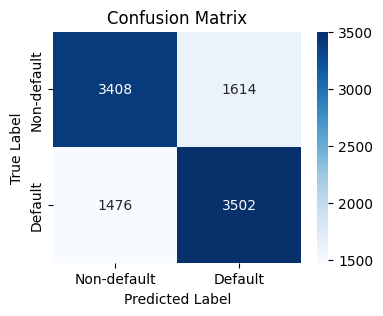

```python
conf_matrix = confusion_matrix(y_test, svm_predictions)

plt.figure(figsize=(4, 3))
sns.heatmap(conf_matrix, annot=True, fmt='d', cmap='Blues', xticklabels=['Non-default', 'Default'], yticklabels=['Non-default', 'Default'])
plt.xlabel('Predicted Label')
plt.ylabel('True Label')
plt.title('Confusion Matrix')
plt.show()
```

ROC Curve

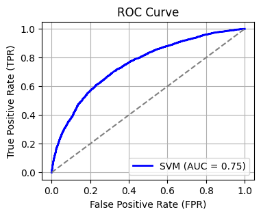

```
SVM Classifier AUC: 0.753716191945476
```

```python
from sklearn.metrics import roc_curve, auc
import matplotlib.pyplot as plt

svm_probabilities = svm_model.predict_proba(X_test)[:, 1]

fpr, tpr, thresholds = roc_curve(y_test, svm_probabilities)

roc_auc = auc(fpr, tpr)

plt.figure(figsize=(4, 3))
plt.plot(fpr, tpr, color='blue', lw=2, label=f'SVM (AUC = {roc_auc:.2f})')
plt.plot([0, 1], [0, 1], color='grey', linestyle='--')

plt.xlabel('False Positive Rate (FPR)')
plt.ylabel('True Positive Rate (TPR)')
plt.title('ROC Curve')
plt.legend(loc='lower right')
plt.grid()
plt.show()

# Print AUC score
print("SVM Classifier AUC:", roc_auc)
```

Precision Recall Curve

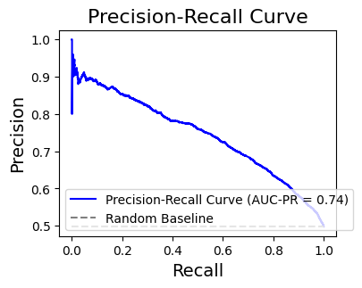

```
Precision-Recall AUC: 0.745
```

```python
from sklearn.metrics import average_precision_score

svm_probabilities = svm_model.predict_proba(X_test)[:, 1]

precision, recall, thresholds = precision_recall_curve(y_test, svm_probabilities)
pr_auc = average_precision_score(y_test, svm_probabilities)

plt.figure(figsize=(4, 3))
plt.plot(recall, precision, color='b', label=f'Precision-Recall Curve (AUC-PR = {pr_auc:.2f})')

plt.hlines(y=np.mean(y_test), xmin=0, xmax=1, linestyle='--', color='gray', label='Random Baseline')

plt.title("Precision-Recall Curve", fontsize=16)
plt.xlabel("Recall", fontsize=14)
plt.ylabel("Precision", fontsize=14)
plt.legend(loc="lower left")

plt.show()

pr_auc = auc(recall, precision)
print(f"Precision-Recall AUC: {pr_auc:.3f}")
```

### 2.3 XGBoost

```python
%pip install xgboost
import xgboost
from xgboost import XGBClassifier
from sklearn.metrics import classification_report, accuracy_score
```

K-Fold Cross-Validation

```python
xgb_model = XGBClassifier(max_depth=4, min_child_weight=6, gamma=0.1, subsample=0.8, colsample_bytree=0.8,
                          learning_rate=0.1, n_estimators=100, use_label_encoder=False, eval_metric='logloss', random_state=42)
kfold = KFold(n_splits=5, shuffle=True, random_state=1)

cv_scores = cross_val_score(svm_model, X_train, y_train, cv=kfold, scoring='accuracy')

print("Cross-validation scores for each fold:", cv_scores)
print("Average cross-validation accuracy: {:.2f}%".format(cv_scores.mean() * 100))
```

```
Cross-validation scores for each fold: [0.690625 0.685875 0.675875 0.68475  0.68525 ]
Average cross-validation accuracy: 68.45%
```

Train the Model

```python
xgb_model.fit(X_train, y_train)
xgb_predictions = xgb_model.predict(X_test)

print("\nXGBoost Classifier with K-Fold Cross-Validation:")
print("Test Accuracy:", accuracy_score(y_test, xgb_predictions))
print("Classification Report:\n", classification_report(y_test, xgb_predictions))
print("Confusion Matrix:\n", confusion_matrix(y_test, xgb_predictions))
```

```
XGBoost Classifier with K-Fold Cross-Validation:
Test Accuracy: 0.6935
Classification Report:
               precision    recall  f1-score   support

         0.0       0.69      0.70      0.70      5022
         1.0       0.69      0.69      0.69      4978

    accuracy                           0.69     10000
   macro avg       0.69      0.69      0.69     10000
weighted avg       0.69      0.69      0.69     10000

Confusion Matrix:
 [[3515 1507]
 [1558 3420]]
```

Confusion Matrix

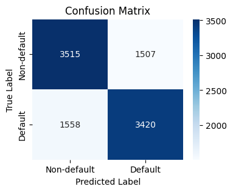

```python
conf_matrix = confusion_matrix(y_test, xgb_predictions)

plt.figure(figsize=(4, 3))
sns.heatmap(conf_matrix, annot=True, fmt='d', cmap='Blues', xticklabels=['Non-default', 'Default'], yticklabels=['Non-default', 'Default'])
plt.xlabel('Predicted Label')
plt.ylabel('True Label')
plt.title('Confusion Matrix')
plt.show()
```

Feature Importance

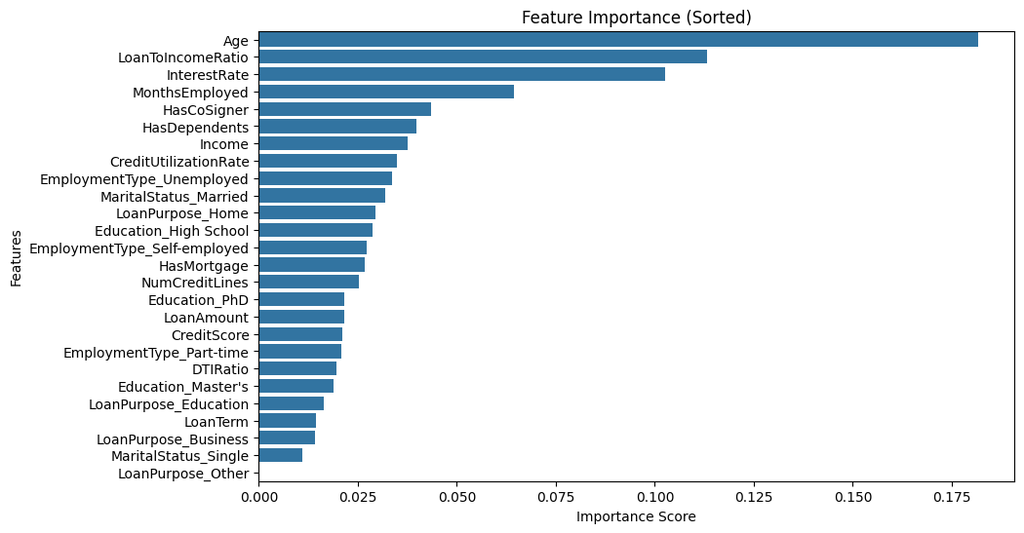

```python
feature_importances = xgb_model.feature_importances_

sorted_idx = np.argsort(feature_importances)[::-1]

sorted_features = X.columns[sorted_idx]
sorted_importances = feature_importances[sorted_idx]

plt.figure(figsize=(10, 6))
sns.barplot(x=sorted_importances, y=sorted_features)
plt.title("Feature Importance (Sorted)")
plt.xlabel("Importance Score")
plt.ylabel("Features")
plt.show()
```

The top 3 important features are Age, LoanToIncomeRatio, InterestRate.

ROC Curve

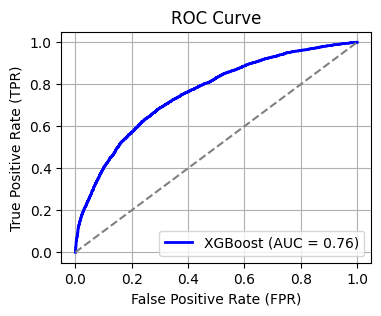

```
XGBoost Classifier AUC: 0.7583030807476433
```

```python
from sklearn.metrics import roc_curve, auc
import matplotlib.pyplot as plt

xgb_probabilities = xgb_model.predict_proba(X_test)[:, 1]

fpr, tpr, thresholds = roc_curve(y_test, xgb_probabilities)

roc_auc = auc(fpr, tpr)

plt.figure(figsize=(4, 3))
plt.plot(fpr, tpr, color='blue', lw=2, label=f'XGBoost (AUC = {roc_auc:.2f})')
plt.plot([0, 1], [0, 1], color='grey', linestyle='--')  # 绘制对角线（代表随机猜测）

plt.xlabel('False Positive Rate (FPR)')
plt.ylabel('True Positive Rate (TPR)')
plt.title('ROC Curve')
plt.legend(loc='lower right')
plt.grid()
plt.show()

# Print AUC score
print("XGBoost Classifier AUC:", roc_auc)
```

Precision Recall Curve

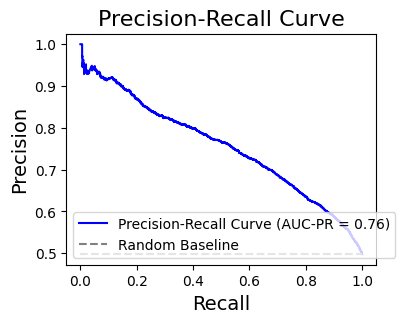

```
Precision-Recall AUC: 0.755
```

```python
from sklearn.metrics import average_precision_score

xgb_probabilities = xgb_model.predict_proba(X_test)[:, 1]

precision, recall, thresholds = precision_recall_curve(y_test, xgb_probabilities)
pr_auc = average_precision_score(y_test, xgb_probabilities)

plt.figure(figsize=(4, 3))
plt.plot(recall, precision, color='b', label=f'Precision-Recall Curve (AUC-PR = {pr_auc:.2f})')

plt.hlines(y=np.mean(y_test), xmin=0, xmax=1, linestyle='--', color='gray', label='Random Baseline')

plt.title("Precision-Recall Curve", fontsize=16)
plt.xlabel("Recall", fontsize=14)
plt.ylabel("Precision", fontsize=14)
plt.legend(loc="lower left")

plt.show()

pr_auc = auc(recall, precision)
print(f"Precision-Recall AUC: {pr_auc:.3f}")
```

### 2.4 Conclusion

**Interpretation of Results:**

**Random Forest**: This model achieved an accuracy of 0.686, with a recall split (0.70 for one class(default=0) and 0.67 for the other), an AUC of 0.748, and a PR AUC of 0.745. The fairly balanced recall suggests that the model identifies both default and non-default cases moderately well but slightly favors one class over the other. Its AUC and PR AUC scores indicate reasonable but not exceptional discriminatory power between classes.

**XGBoost**: XGBoost delivered the best overall performance across most metrics, with an accuracy of 0.694 and recall (0.70/0.69) close to balanced between the two classes. The AUC of 0.758 and PR AUC of 0.755 suggest that XGBoost is slightly better at distinguishing between default and non-default loans than Random Forest. This improvement in AUC and PR AUC highlights its effectiveness in capturing patterns within the data.

**SVM (Support Vector Machine)**: The SVM model achieved an accuracy of 0.691 and recall(0.68/0.70). Its AUC was 0.754, slightly lower than XGBoost but comparable to Random Forest. The PR AUC of 0.745 matches that of Random Forest, indicating that while SVM has a similar balance in class detection, it does not outperform XGBoost in terms of discriminative ability.

**Conclusion**:  
Among the three models, **XGBoost** exhibits the highest performance, achieving the best results for accuracy, AUC, and PR AUC, making it the most effective model for this dataset in predicting loan defaults. Its recall is also fairly balanced, indicating good generalization across classes. So XGBoost is the most suitable choice for loan default prediction in this context.

## 3. Unsupervised Learning

Choose three unsupervised learning method for dimensionality reduction: **PCA, Kernel PCA, and t-SNE**. Then use classification method **K-Means** to classify the data after dimensionality reduction.  
(Notice that we also ues antoencoder to reduce dimension, but the result isn't good, so drop this choice)

```python
from sklearn.decomposition import PCA
from sklearn.cluster import KMeans
from sklearn.metrics import accuracy_score, classification_report
```

### 3.1 Preprocessing Data

Unsupervised learning may not be affected by dataset imbalance, so consider applying the entire dataset first.

```python
dataU = pd.read_csv('E:/0AAANUS/sem1/hw-ml/Loan_default.csv')
dataU.drop("LoanID", axis = 1, inplace = True)
dataU.head()
```

|  | Age | Income | LoanAmount | CreditScore | MonthsEmployed | NumCreditLines | InterestRate | LoanTerm | DTIRatio | Education | EmploymentType | MaritalStatus | HasMortgage | HasDependents | LoanPurpose | HasCoSigner | Default |
| --- | --- | --- | --- | --- | --- | --- | --- | --- | --- | --- | --- | --- | --- | --- | --- | --- | --- |
| 0 | 56 | 85994 | 50587 | 520 | 80 | 4 | 15.23 | 36 | 0.44 | Bachelor's | Full-time | Divorced | Yes | Yes | Other | Yes | 0 |
| 1 | 69 | 50432 | 124440 | 458 | 15 | 1 | 4.81 | 60 | 0.68 | Master's | Full-time | Married | No | No | Other | Yes | 0 |
| 2 | 46 | 84208 | 129188 | 451 | 26 | 3 | 21.17 | 24 | 0.31 | Master's | Unemployed | Divorced | Yes | Yes | Auto | No | 1 |
| 3 | 32 | 31713 | 44799 | 743 | 0 | 3 | 7.07 | 24 | 0.23 | High School | Full-time | Married | No | No | Business | No | 0 |
| 4 | 60 | 20437 | 9139 | 633 | 8 | 4 | 6.51 | 48 | 0.73 | Bachelor's | Unemployed | Divorced | No | Yes | Auto | No | 0 |

```python
pd.Series(dataU['Default']).value_counts()
```

```
Default
0    225694
1     29653
Name: count, dtype: int64
```

```python
# check missing data
print(dataU.shape)
print('\t')
print(dataU.isnull().sum())
print('\t')
dataU.info()
```

```
(255347, 17)

Age               0
Income            0
LoanAmount        0
CreditScore       0
MonthsEmployed    0
NumCreditLines    0
InterestRate      0
LoanTerm          0
DTIRatio          0
Education         0
EmploymentType    0
MaritalStatus     0
HasMortgage       0
HasDependents     0
LoanPurpose       0
HasCoSigner       0
Default           0
dtype: int64

<class 'pandas.core.frame.DataFrame'>
RangeIndex: 255347 entries, 0 to 255346
Data columns (total 17 columns):
 #   Column          Non-Null Count   Dtype
---  ------          --------------   -----
 0   Age             255347 non-null  int64
 1   Income          255347 non-null  int64
 2   LoanAmount      255347 non-null  int64
 3   CreditScore     255347 non-null  int64
 4   MonthsEmployed  255347 non-null  int64
 5   NumCreditLines  255347 non-null  int64
 6   InterestRate    255347 non-null  float64
 7   LoanTerm        255347 non-null  int64
 8   DTIRatio        255347 non-null  float64
 9   Education       255347 non-null  object
 10  EmploymentType  255347 non-null  object
 11  MaritalStatus   255347 non-null  object
 12  HasMortgage     255347 non-null  object
 13  HasDependents   255347 non-null  object
 14  LoanPurpose     255347 non-null  object
 15  HasCoSigner     255347 non-null  object
 16  Default         255347 non-null  int64
dtypes: float64(2), int64(8), object(7)
memory usage: 33.1+ MB
```

Lable Encoding

For both categorical data and binary data, use label encoder.

```python
print(dataU.columns)
```

```
Index(['Age', 'Income', 'LoanAmount', 'CreditScore', 'MonthsEmployed',
       'NumCreditLines', 'InterestRate', 'LoanTerm', 'DTIRatio', 'Education',
       'EmploymentType', 'MaritalStatus', 'HasMortgage', 'HasDependents',
       'LoanPurpose', 'HasCoSigner', 'Default'],
      dtype='object')
```

```python
from sklearn.preprocessing import LabelEncoder

categorical_columns = ['Education', 'EmploymentType', 'MaritalStatus', 'LoanPurpose']
binary_columns = ['HasMortgage', 'HasDependents', 'HasCoSigner']

le = LabelEncoder()
for col in categorical_columns:
    dataU[col] = le.fit_transform(dataU[col])
for col in binary_columns:
    dataU[col] = le.fit_transform(dataU[col])


print(dataU.head())
```

```
   Age  Income  LoanAmount  CreditScore  MonthsEmployed  NumCreditLines  \
0   56   85994       50587          520              80               4
1   69   50432      124440          458              15               1
2   46   84208      129188          451              26               3
3   32   31713       44799          743               0               3
4   60   20437        9139          633               8               4

   InterestRate  LoanTerm  DTIRatio  Education  EmploymentType  MaritalStatus  \
0         15.23        36      0.44          0               0              0
1          4.81        60      0.68          2               0              1
2         21.17        24      0.31          2               3              0
3          7.07        24      0.23          1               0              1
4          6.51        48      0.73          0               3              0

   HasMortgage  HasDependents  LoanPurpose  HasCoSigner  Default
0            1              1            4            1        0
1            0              0            4            1        0
2            1              1            0            0        1
3            0              0            1            0        0
4            0              1            0            0        0
```

Feature Engineering

```python
dataU['LoanToIncomeRatio'] = dataU['LoanAmount'] / dataU['Income']
dataU['CreditUtilizationRate'] = dataU['LoanAmount'] / dataU['CreditScore']
```

Standardization

```python
from sklearn.preprocessing import StandardScaler

# List of numerical columns to scale
numerical_columns = ['Age', 'Income', 'LoanAmount', 'CreditScore', 'MonthsEmployed',
                     'NumCreditLines', 'InterestRate', 'LoanTerm', 'DTIRatio', 'LoanToIncomeRatio' , 'CreditUtilizationRate',
                     ]
scaler = StandardScaler()
dataU[numerical_columns] = scaler.fit_transform(dataU[numerical_columns])
dataU.head()
```

|  | Age | Income | LoanAmount | CreditScore | MonthsEmployed | NumCreditLines | InterestRate | LoanTerm | DTIRatio | Education | EmploymentType | MaritalStatus | HasMortgage | HasDependents | LoanPurpose | HasCoSigner | Default | LoanToIncomeRatio | CreditUtilizationRate |
| --- | --- | --- | --- | --- | --- | --- | --- | --- | --- | --- | --- | --- | --- | --- | --- | --- | --- | --- | --- |
| 0 | 0.833990 | 0.089693 | -1.086833 | -0.341492 | 0.590533 | 1.341937 | 0.261771 | -0.001526 | -0.260753 | 0 | 0 | 0 | 1 | 1 | 4 | 1 | 0 | -0.729550 | -0.910750 |
| 1 | 1.701221 | -0.823021 | -0.044309 | -0.731666 | -1.285731 | -1.343791 | -1.308350 | 1.412793 | 0.778585 | 2 | 0 | 1 | 0 | 0 | 4 | 1 | 0 | 0.133129 | 0.187890 |
| 2 | 0.166888 | 0.043854 | 0.022715 | -0.775718 | -0.968209 | 0.446694 | 1.156831 | -0.708685 | -0.823728 | 2 | 3 | 0 | 1 | 1 | 0 | 0 | 1 | -0.295327 | 0.280765 |
| 3 | -0.767053 | -1.303452 | -1.168538 | 1.061875 | -1.718715 | 0.446694 | -0.967805 | -0.708685 | -1.170174 | 1 | 0 | 1 | 0 | 0 | 1 | 0 | 0 | -0.351110 | -1.143730 |
| 4 | 1.100830 | -1.592855 | -1.671921 | 0.369631 | -1.487790 | 1.341937 | -1.052188 | 0.705634 | 0.995114 | 0 | 3 | 0 | 0 | 1 | 0 | 0 | 0 | -0.794316 | -1.432576 |

Train test split

```python
from sklearn.model_selection import train_test_split

# Split the dataset into features and target variable
X2 = dataU.drop('Default', axis=1)  # Features
y2 = dataU['Default']  # Target variable
```

```python
pd.Series(y2).value_counts()
```

```
Default
0    225694
1     29653
Name: count, dtype: int64
```

### 3.2 PCA

#### 3.2.2 PCA+KMeans

Use PCA method to reduce the dimension of features, let n=5

```python
pca = PCA(n_components=5)
X_pca = pca.fit_transform(X2)
```

Use kmeans clustering on the reduced dimensionality data, let n=2 to distinguish whether it is default.

```python
kmeans = KMeans(n_clusters=2, random_state=42)
kmeans.fit(X_pca)
cluster_labels = kmeans.labels_
```

```python
results = pd.DataFrame({'Actual': y2, 'Cluster Label': cluster_labels})
print(results.head())
```

```
   Actual  Cluster Label
0       0              0
1       0              1
2       1              1
3       0              0
4       0              0
```

Visualize the results

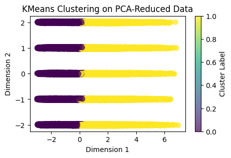

```python
plt.figure(figsize=(5, 3))
plt.scatter(X_pca[:, 0], X_pca[:, 1], c=cluster_labels, cmap='viridis', s=50, alpha=0.7)
plt.title('KMeans Clustering on PCA-Reduced Data')
plt.xlabel('Dimension 1')
plt.ylabel('Dimension 2')
plt.colorbar(label='Cluster Label')
plt.show()
```

Compute the classification accuracy.

```python
y2_array = np.array(y2)
# Calculate the match between cluster labels and y_train
accuracy = max(accuracy_score(y2_array, cluster_labels),
               accuracy_score(y2_array, 1 - cluster_labels))  # Reversing label calculations for another case

print("Clustering Accuracy with best alignment:", accuracy)
print(classification_report(y2_array, cluster_labels))
```

```
Clustering Accuracy with best alignment: 0.575644123486863
              precision    recall  f1-score   support

           0       0.91      0.58      0.71    225694
           1       0.15      0.58      0.24     29653

    accuracy                           0.58    255347
   macro avg       0.53      0.58      0.47    255347
weighted avg       0.82      0.58      0.65    255347
```

The results shows that the clustering accuracy is 0.57, but we can see that the accuracy on default=1 is low, so this model doesn't perform well, so try kernel PCA

use balanced data subset:

```python
data_sampled_PCA = dataU.groupby("Default").sample(n=25000, random_state=42)

# Separate features and target before scaling
X_sampled_PCA = data_sampled_PCA.drop('Default', axis=1)  # Features
y_sampled_PCA = data_sampled_PCA['Default']

pca = PCA(n_components=5)
X_pca = pca.fit_transform(X_sampled_PCA)
kmeans = KMeans(n_clusters=2, random_state=42)
kmeans.fit(X_pca)
cluster_labels = kmeans.labels_
y2_array = np.array(y_sampled_PCA)
# Calculate the match between cluster labels and y_train
accuracy = max(accuracy_score(y2_array, cluster_labels),
               accuracy_score(y2_array, 1 - cluster_labels))  # Reversing label calculations for another case

print("Clustering Accuracy with best alignment:", accuracy)
print(classification_report(y2_array, cluster_labels))
```

```
Clustering Accuracy with best alignment: 0.58382
              precision    recall  f1-score   support

           0       0.57      0.69      0.62     25000
           1       0.61      0.48      0.53     25000

    accuracy                           0.58     50000
   macro avg       0.59      0.58      0.58     50000
weighted avg       0.59      0.58      0.58     50000
```

We can see that after balanced the dataset, the model performs better than before, but still worse than supervised learning method.

#### 3.2.3 KernelPCA

```python
from sklearn.decomposition import KernelPCA
from sklearn.preprocessing import StandardScaler
import matplotlib.pyplot as plt
```

The model cannot handle a large amount of data, so we take a data subset with a sample size of 10,000, and choose the rbf kernel.

```python
# Sample a smaller subset of data
data_sampled = dataX.sample(n=10000, random_state=42)  # Reduce sample size to 10,000

# Separate features and target before scaling
X_sampled = data_sampled.drop('Default', axis=1)  # Features
y_sampled = data_sampled['Default']  # Target variable

# Scale the numerical columns
data_scaled = scaler.fit_transform(X_sampled[numerical_columns])  # Scaling only features

# Perform Kernel PCA on the scaled data
kpca = KernelPCA(kernel="rbf", gamma=0.1, n_components=3)
data_kpca = kpca.fit_transform(data_scaled)
```

```python
kmeans = KMeans(n_clusters=2, random_state=42)
kmeans.fit(data_kpca)
cluster_labels = kmeans.labels_
```

```python
results = pd.DataFrame({'Actual': y_sampled, 'Cluster Label': cluster_labels})

results['Cluster Label'] = np.where(results['Cluster Label'] == 0, 1, 0)

print(results.head())
```

```
        Actual  Cluster Label
55225      1.0              1
10431      0.0              0
193964     0.0              0
147541     0.0              0
191064     1.0              1
```

Clustering Accuracy

```python
y2_array = np.array(y_sampled)

accuracy = max(accuracy_score(y2_array, cluster_labels),
               accuracy_score(y2_array, 1 - cluster_labels))

print("Clustering Accuracy with best alignment:", accuracy)
print(classification_report(y2_array, cluster_labels))
```

```
Clustering Accuracy with best alignment: 0.5714
              precision    recall  f1-score   support

         0.0       0.58      0.56      0.57      5022
         1.0       0.57      0.59      0.58      4978

    accuracy                           0.57     10000
   macro avg       0.57      0.57      0.57     10000
weighted avg       0.57      0.57      0.57     10000
```

Visualization

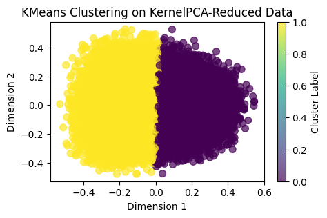

```python
plt.figure(figsize=(5, 3))
plt.scatter(data_kpca[:, 0], data_kpca[:, 1], c=cluster_labels, cmap='viridis', s=50, alpha=0.7)
plt.title('KMeans Clustering on KernelPCA-Reduced Data')
plt.xlabel('Dimension 1')
plt.ylabel('Dimension 2')
plt.colorbar(label='Cluster Label')
plt.show()
```

use balanced data:

```python
data_sampled_PCAk = dataU.groupby("Default").sample(n=5000, random_state=42)  # Reduce sample size to 10,000

# Separate features and target before scaling
X_sampled_PCAk = data_sampled_PCAk.drop('Default', axis=1)  # Features
y_sampled_PCAk = data_sampled_PCAk['Default']
kpca2 = KernelPCA(kernel="rbf", gamma=0.1, n_components=3)
data_kpca2 = kpca.fit_transform(X_sampled_PCAk)
kmeans = KMeans(n_clusters=2, random_state=42)
kmeans.fit(data_kpca2)
cluster_labels2 = kmeans.labels_
y2_array = np.array(y_sampled_PCAk)

accuracy = accuracy_score(y2_array, cluster_labels2),


print("Clustering Accuracy with best alignment:", accuracy)
print(classification_report(y2_array, cluster_labels2))
```

```
Clustering Accuracy with best alignment: (0.4237,)
              precision    recall  f1-score   support

           0       0.42      0.43      0.43      5000
           1       0.42      0.42      0.42      5000

    accuracy                           0.42     10000
   macro avg       0.42      0.42      0.42     10000
weighted avg       0.42      0.42      0.42     10000
```

### 3.3 t-SNE

```python
from sklearn.manifold import TSNE
```

```python
tsne = TSNE(n_components=2, random_state=42)
X_tsne = tsne.fit_transform(X2)
```

```python
kmeans = KMeans(n_clusters=2, random_state=42)
cluster_labels = kmeans.fit_predict(X_tsne)
```

Visualization

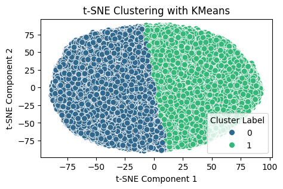

```python
plt.figure(figsize=(5, 3))
sns.scatterplot(x=X_tsne[:, 0], y=X_tsne[:, 1], hue=cluster_labels, palette="viridis", s=50)
plt.title("t-SNE Clustering with KMeans")
plt.xlabel("t-SNE Component 1")
plt.ylabel("t-SNE Component 2")
plt.legend(title="Cluster Label", loc="best")
plt.show()
```

```python
results = pd.DataFrame({'Actual': y2, 'Cluster Label': cluster_labels})
print(results.head())
```

```
   Actual  Cluster Label
0       0              0
1       0              1
2       1              0
3       0              0
4       0              0
```

Accuracy

```python
y2_array = np.array(y2)

accuracy = max(accuracy_score(y2_array, cluster_labels),
               accuracy_score(y2_array, 1 - cluster_labels))

print("Clustering Accuracy with best alignment:", accuracy)
print(classification_report(y2_array, cluster_labels))
```

```
Clustering Accuracy with best alignment: 0.5323657611015599
              precision    recall  f1-score   support

           0       0.91      0.52      0.66    225694
           1       0.14      0.61      0.23     29653

    accuracy                           0.53    255347
   macro avg       0.53      0.56      0.45    255347
weighted avg       0.82      0.53      0.61    255347
```

use balanced data:

```python
tsne = TSNE(n_components=2, random_state=42)
X_tsne = tsne.fit_transform(X_sampled_PCA)
kmeans = KMeans(n_clusters=2, random_state=42)
cluster_labels = kmeans.fit_predict(X_tsne)
y2_array = np.array(y_sampled_PCA)

accuracy = max(accuracy_score(y2_array, cluster_labels),
               accuracy_score(y2_array, 1 - cluster_labels))

print("Clustering Accuracy with best alignment:", accuracy)
print(classification_report(y2_array, cluster_labels))
```

```
Clustering Accuracy with best alignment: 0.58214
              precision    recall  f1-score   support

           0       0.58      0.61      0.59     25000
           1       0.59      0.56      0.57     25000

    accuracy                           0.58     50000
   macro avg       0.58      0.58      0.58     50000
weighted avg       0.58      0.58      0.58     50000
```

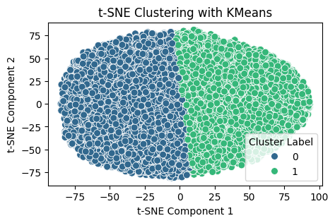

```python
plt.figure(figsize=(5, 3))
sns.scatterplot(x=X_tsne[:, 0], y=X_tsne[:, 1], hue=cluster_labels, palette="viridis", s=50)
plt.title("t-SNE Clustering with KMeans")
plt.xlabel("t-SNE Component 1")
plt.ylabel("t-SNE Component 2")
plt.legend(title="Cluster Label", loc="best")
plt.show()
```

The result shows that by using balanced data, the accuracy of t-SNE has improved from 0.53 to 0.58, especially for the accuracy of data that default=1.

### 3.4 Autoencoder

```python
%pip install tensorflow
```

[output not shown]

```python
import tensorflow
```

```python
from tensorflow.keras.models import Model
from tensorflow.keras.layers import Input, Dense
```

```python
print(X2.columns)
```

```
Index(['Age', 'Income', 'LoanAmount', 'CreditScore', 'MonthsEmployed',
       'NumCreditLines', 'InterestRate', 'LoanTerm', 'DTIRatio', 'Education',
       'EmploymentType', 'MaritalStatus', 'HasMortgage', 'HasDependents',
       'LoanPurpose', 'HasCoSigner', 'LoanToIncomeRatio',
       'CreditUtilizationRate'],
      dtype='object')
```

```python
input_dim = X2.shape[1]
encoding_dim = 4

# input layer
input_layer = Input(shape=(input_dim,))
# encode layer
encoded = Dense(10, activation='relu')(input_layer)
encoded = Dense(encoding_dim, activation='relu')(encoded)

# decode layer
decoded = Dense(10, activation='relu')(encoded)
decoded = Dense(input_dim, activation='sigmoid')(decoded)

# model
autoencoder = Model(inputs=input_layer, outputs=decoded)
autoencoder.compile(optimizer='adam', loss='mse')
```

```python
# train Autoencoder
autoencoder.fit(X2, X2, epochs=50, batch_size=64, shuffle=True, validation_split=0.2)

# define encoder
encoder = Model(inputs=input_layer, outputs=encoded)

# 2. Use encoder to reduce data to low dimensional space
X_encoded = encoder.predict(X2)
```

[output not shown]

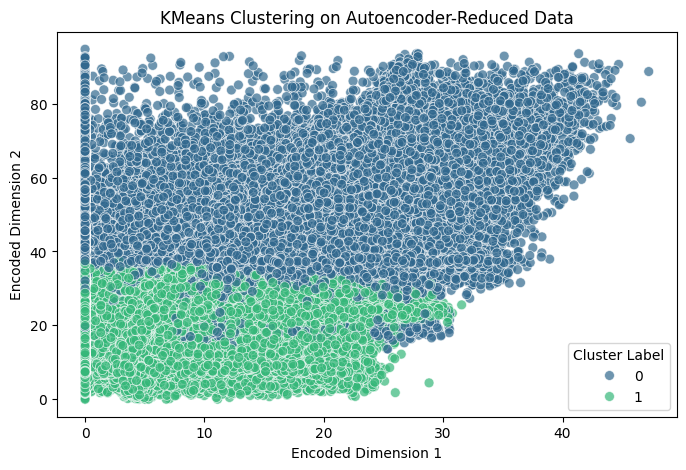

```python
# 3. Apply KMeans clustering to the reduced data
kmeans = KMeans(n_clusters=2, random_state=42)
cluster_labels = kmeans.fit_predict(X_encoded)

# 4. visualization
plt.figure(figsize=(8, 5))
sns.scatterplot(x=X_encoded[:, 0], y=X_encoded[:, 1], hue=cluster_labels, palette="viridis", s=50, alpha=0.7)
plt.title('KMeans Clustering on Autoencoder-Reduced Data')
plt.xlabel('Encoded Dimension 1')
plt.ylabel('Encoded Dimension 2')
plt.legend(title='Cluster Label')  # Use legend for cluster labels
plt.show()
```

Accuracy

```python
y2_array = np.array(y2)

accuracy = max(accuracy_score(y2_array, cluster_labels),
               accuracy_score(y2_array, 1 - cluster_labels))

print("Clustering Accuracy with best alignment:", accuracy)
print(classification_report(y2_array, cluster_labels))
```

```
Clustering Accuracy with best alignment: 0.5693781403345252
              precision    recall  f1-score   support

           0       0.89      0.41      0.56    225694
           1       0.12      0.60      0.20     29653

    accuracy                           0.43    255347
   macro avg       0.50      0.50      0.38    255347
weighted avg       0.80      0.43      0.52    255347
```

use balanced data:

```python
input_dim = X_sampled_PCA.shape[1]
encoding_dim = 4


input_layer = Input(shape=(input_dim,))

encoded = Dense(10, activation='relu')(input_layer)
encoded = Dense(encoding_dim, activation='relu')(encoded)


decoded = Dense(10, activation='relu')(encoded)
decoded = Dense(input_dim, activation='sigmoid')(decoded)


autoencoder = Model(inputs=input_layer, outputs=decoded)
autoencoder.compile(optimizer='adam', loss='mse')
```

```python
autoencoder.fit(X_sampled_PCA, X_sampled_PCA, epochs=50, batch_size=64, shuffle=True, validation_split=0.2)
encoder = Model(inputs=input_layer, outputs=encoded)

X_encoded = encoder.predict(X_sampled_PCA)
```

[output not shown]

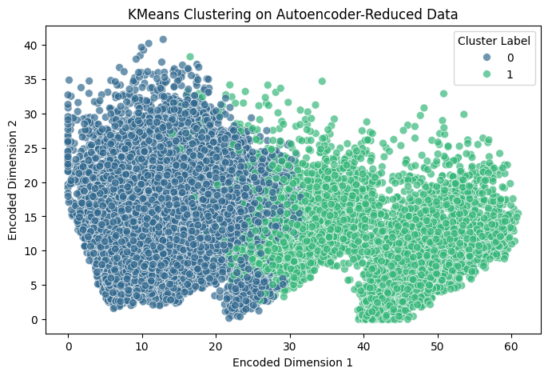

```python
kmeans = KMeans(n_clusters=2, random_state=42)
cluster_labels = kmeans.fit_predict(X_encoded)

plt.figure(figsize=(8, 5))
sns.scatterplot(x=X_encoded[:, 0], y=X_encoded[:, 1], hue=cluster_labels, palette="viridis", s=50, alpha=0.7)
plt.title('KMeans Clustering on Autoencoder-Reduced Data')
plt.xlabel('Encoded Dimension 1')
plt.ylabel('Encoded Dimension 2')
plt.legend(title='Cluster Label')  # Use legend for cluster labels
plt.show()
```

```python
y2_array = np.array(y_sampled_PCA)

accuracy = max(accuracy_score(y2_array, cluster_labels),
               accuracy_score(y2_array, 1 - cluster_labels))

print("Clustering Accuracy with best alignment:", accuracy)
print(classification_report(y2_array, cluster_labels))
```

```
Clustering Accuracy with best alignment: 0.50278
              precision    recall  f1-score   support

           0       0.50      0.88      0.64     25000
           1       0.51      0.12      0.20     25000

    accuracy                           0.50     50000
   macro avg       0.51      0.50      0.42     50000
weighted avg       0.51      0.50      0.42     50000
```

### 3.5 Conclusion

**Interpretation of the results:**

**PCA** (Principal Component Analysis):  
With imbalanced data, PCA achieves an accuracy of 0.575 and an F1-score of 0.71 for default=0 and 0.24 for default=1. On balanced data, PCA shows a slight improvement with an accuracy of 0.583 and F1-scores of 0.62 and 0.53.  
This suggests that PCA performs relatively better with balanced data.

**t-SNE** (t-Distributed Stochastic Neighbor Embedding):  
For imbalanced data, t-SNE shows an accuracy of 0.532 and F1-scores of 0.66 and 0.23, with performance fairly low on default=1.  
On balanced data, its accuracy improves to 0.582, with F1-scores of 0.59 and 0.57, indicating it benefits from balanced data.  
t-SNE, like PCA, is more influenced by data imbalance but shows improvements with balanced data.

## 4. Conclusion

### 4.1 Model Selection

The supervised learning models (Random Forest, XGBoost, and SVM) generally perform better compared to the unsupervised methods (PCA, Kernel PCA, and t-SNE). This is indicated by higher accuracy, recall, f1-score values in the supervised models.

This is likely because supervised learning methods are trained with labeled data, allowing the models to learn directly from the specific patterns related to the target variable (e.g., loan default). Unsupervised learning methods, however, do not have access to the labels during training and rely on clustering or dimensionality reduction, which may not capture the complex relationships needed for accurate predictions in a classification task.

In summary, supervised learning models perform significantly better than unsupervised models due to their ability to learn directly from labeled data, and among the supervised models, **XGBoost** achieves the best overall performance.

### 4.2 Top 3 Feature Impact on Loan Default Prediction

**Age**: Younger borrowers may have less financial stability and credit history, leading to a higher risk of default. Older borrowers might have established credit but could be affected by other factors like health or retirement, influencing their default risk differently.

**Loan-to-Income Ratio**: This ratio measures how much of the borrower’s income is used to repay the loan. Higher values indicate a larger debt burden relative to income, increasing default likelihood due to financial strain.

**Interest Rate**: Higher interest rates increase monthly payments, making it harder for borrowers to keep up with repayments, which can raise the risk of default.

### 4.3 Economic Value of Loan Default Prediction

Finally, talk about the economic value of loan default prediction.

Accurate prediction of loan defaults enables lenders to assess borrower risk effectively. This helps reduce financial losses, optimize loan portfolios, and improve capital allocation. Moreover, identifying high-risk loans can support lenders in setting appropriate interest rates or collateral requirements, ultimately contributing to a healthier credit market and enhancing financial stability.

In summary, this project utilizes machine learning models to predict loan defaults, providing a data-driven approach to identify high-risk loans. This enhances risk assessment, supports more informed lending decisions, and ultimately contributes to reducing financial losses in the credit market.